# Convolution and Impulsive Sources

MATH 341 — Notes 8

University of Scranton

2026-10-04

# Goals

## What We Will Cover

1. **Convolution** $(x*y)(t) = \int_0^t x(\tau)\,y(t-\tau)\,d\tau$ — definition and direct computation
2. **Convolution property** $\mathscr{L}[x*y] = X(s)\,Y(s)$ — inverting products of transforms
3. **Commutativity** $x*y = y*x$ — choosing the easier arrangement
4. **Arbitrary forcing** — solution formulas via convolution integrals
5. **Impulsive sources** — the physical motivation for $\delta_a(t)$
6. **Sifting property** and $\mathscr{L}[\delta_a(t)] = e^{-as}$
7. **Transfer functions** and input–output systems

**Note**

**Sections 3.3 and 3.4** of (Logan 2015).

**Tip**

New vocabulary: convolution, sifting property, delta function, generalized function, transfer function, impulse response.

# Section 3.3

## The Convolution Property

## Products of Transforms — The Key Question

We know Laplace transforms respect **sums**:
$$\mathscr{L}[x+y] = X(s) + Y(s).$$

**Natural question:** what about products of functions?

$$\mathscr{L}[x(t)\,y(t)] = \;?$$

**Warning**

$$\mathscr{L}[x(t)\,y(t)] \neq X(s)\,Y(s)$$
The transform of a **product is not** the product of the transforms. (Exercise 2, §3.3 asks for a concrete counterexample.)

The right question is the **inverse** one: what function *has* transform $X(s)\,Y(s)$?

## Definition: Convolution

**Definition**

Let $x(t)$ and $y(t)$ be defined on $[0,\infty)$. The **convolution** of $x$ and $y$, denoted $x * y$, is
$$(x * y)(t) = \int_0^t x(\tau)\,y(t - \tau)\,d\tau.$$

**How to read the integral:** for fixed $t$, substitute $\tau$ for the argument of $x$ and $t-\tau$ for the argument of $y$ (flipping and shifting $y$), then integrate from $0$ to $t$.

## Why This Structure? — Memory and History

**Tip**

Think of the integral as a *weighted accumulation of history*: it combines the past values of $x$ against a time-reversed, shifted copy of $y$.

This memory structure arises naturally whenever a system’s current output depends on all of its past inputs — exactly the behavior encoded in a forced differential equation.

**The key question** the convolution answers:

> Given two transforms $X(s)$ and $Y(s)$, what time-domain function has transform equal to their *product* $X(s)\,Y(s)$?

The answer — the **Convolution Theorem** — is on the next slide.

## The Convolution Property

**Theorem: Convolution Property**

If $\mathscr{L}[x] = X(s)$ and $\mathscr{L}[y] = Y(s)$, then
$$\mathscr{L}[x * y] = X(s)\,Y(s).$$

Equivalently,
$$\mathscr{L}^{-1}[X(s)\,Y(s)] = (x * y)(t) = \int_0^t x(\tau)\,y(t-\tau)\,d\tau.$$

**Why this matters:** solving a DE via Laplace transforms almost always produces a *product* of transforms $X(s) = K(s)\,F(s)$. The convolution property tells us exactly how to invert it.

## Proof Sketch

Start from the definition, pull $e^{-st}$ inside, then **interchange the order of integration**. The region $0 \le \tau \le t < \infty$ is the same as $0 \le \tau < \infty$, $\tau \le t < \infty$:

$$\mathscr{L}\!\left[\int_0^t x(\tau)\,y(t-\tau)\,d\tau\right]
= \int_0^\infty\!\left(\int_\tau^\infty y(t-\tau)\,e^{-st}\,dt\right)x(\tau)\,d\tau.$$

**Substitute** $r = t-\tau$ in the inner integral:

$$= \int_0^\infty\!\left(\int_0^\infty y(r)\,e^{-sr}\,dr\right)e^{-s\tau}\,x(\tau)\,d\tau
= \left(\int_0^\infty e^{-s\tau}x(\tau)\,d\tau\right)\!\left(\int_0^\infty y(r)e^{-sr}\,dr\right)
= X(s)\,Y(s). \;\square$$

## Commutativity of Convolution

**Remark 3.23**

$$(x * y)(t) = (y * x)(t).$$
Convolution is **commutative**. (Proved by a change of variables — Exercise 5, §3.3.)

**Practical Consequence**

You can choose **which function to shift** when setting up the integral. Always pick the arrangement that makes the integration easier.

In Example 3.22 below, shifting the constant $1$ is far simpler than shifting $t^2$.

## Example 3.22 — Computing $1 * t^2$ Directly

**Find the convolution $1 * t^2$.**

Apply the definition with $x(\tau) = 1$, $y(t-\tau) = (t-\tau)^2$:

$$1 * t^2 = \int_0^t 1\cdot(t-\tau)^2\,d\tau = \int_0^t(t^2-2t\tau+\tau^2)\,d\tau
= t^2\cdot t - 2t\!\left(\frac{t^2}{2}\right)+\frac{t^3}{3} = \frac{t^3}{3}.$$

**Verify via commutativity** — shift the simpler function instead:

$$t^2 * 1 = \int_0^t \tau^2\cdot 1\,d\tau = \frac{t^3}{3}. \checkmark$$

The second calculation is shorter because shifting the constant $1$ changes nothing. **Commutativity always gives you this option.** $\square$

## Example 3.24 — Inverse Transform via Convolution

**Find** $\mathscr{L}^{-1}\!\left[\dfrac{3}{s(s^2+9)}\right]$.

We can use partial fractions, but convolution is more direct. **Factor** into recognizable table entries:

$$\frac{3}{s(s^2+9)} = \underbrace{\frac{1}{s}}_{\mathscr{L}^{-1}\;\to\; 1}\cdot\underbrace{\frac{3}{s^2+9}}_{\mathscr{L}^{-1}\;\to\;\sin 3t}$$

**Apply the convolution property:**
$$\mathscr{L}^{-1}\!\left[\frac{3}{s(s^2+9)}\right] = 1 * \sin 3t = \int_0^t \sin 3\tau\,d\tau$$

**Evaluate:**
$$= \left[-\frac{1}{3}\cos 3\tau\right]_0^t = \boxed{\frac{1}{3}(1-\cos 3t).} \;\square$$

```python
s_v, t_v = sym.symbols('s t', positive=True)
X_24 = sym.Integer(3)/(s_v*(s_v**2+9))
x_24 = sym.inverse_laplace_transform(X_24, s_v, t_v)
display(Math(r"\mathscr{L}^{-1}\!\left[\frac{3}{s(s^2+9)}\right] = " + sym.latex(sym.simplify(x_24))))
```

$\displaystyle \mathscr{L}^{-1}\!\left[\frac{3}{s(s^2+9)}\right] = \frac{1}{3} - \frac{\cos{\left(3 t \right)}}{3}$

## Example 3.25 — DE with Arbitrary Forcing

Solve $x'' + k^2 x = f(t)$, $x(0)=x_0$, $x'(0)=x_1$, for **any** input $f(t)$.

**Transform and solve for $X(s)$:**
$$X(s) = x_0\,\frac{s}{s^2+k^2} + x_1\,\frac{1}{s^2+k^2} + \frac{F(s)}{s^2+k^2}.$$

**Invert** — table for the first two terms, convolution on the last:

$$\boxed{x(t) = x_0\cos kt + \frac{x_1}{k}\sin kt + \frac{1}{k}\int_0^t f(\tau)\sin k(t-\tau)\,d\tau.}$$

**Note**

This formula is valid for **any** forcing $f(t)$ — we never need to know the explicit form of $f$ to write it down. The convolution integral absorbs all the complexity of the input into a single expression. $\square$

## Integral Equations (§3.3, Exercises 14–17)

The convolution property also solves **integral equations** — equations where the unknown $x(t)$ appears under an integral. An important class:

$$x(t) = f(t) + \int_0^t k(t-\tau)\,x(\tau)\,d\tau \qquad (k = \text{kernel}).$$

Take $\mathscr{L}$ of both sides and recognise the convolution:

$$X(s) = F(s) + K(s)\,X(s) \implies X(s) = \frac{F(s)}{1-K(s)}.$$

Then invert $X(s)$ to find $x(t)$.

# Section 3.4

## Impulsive Sources

## Motivation — Forces Acting in an Instant

Some forcing terms act at a **single instant of time**:

- Mass struck by a **swift hammer blow**
- **Medication injection** idealized as instantaneous
- Electrical **switch closed for only an instant** → impulsive voltage
- Shock absorber hitting a **bump in the road**

We need a mathematical model for a force that:

- Acts at a **single point** $t = a$
- Still has **nonzero total effect** (unit area)

This leads to the **delta function** $\delta_a(t)$.

## A Naive Definition Fails

Consider the damped mass $mv' + v = f(t)$, $v(0)=0$. By Laplace / convolution:

$$v(t) = \frac{1}{m}\int_0^t e^{-(t-\tau)/m}\,f(\tau)\,d\tau. \tag{3.9}$$

**Naive definition:** set $\delta_a(t) = 1$ if $t=a$, zero otherwise.

**Problem:** substituting into (3.9) gives $v(t) = 0$ for all $t$. The integrand is nonzero at only one point, which does not contribute to the integral.

**This is physically wrong**

A particle struck by a hammer that never moves is nonsensical. The pointwise definition fails. We need a fundamentally different approach.

## The Physical Intuition: Impulse = Change in Momentum

In physics, **impulse** = change in momentum: $\Delta p = f(t)\,\Delta t$.

For a unit impulse centered at $t=a$ over interval $(a-\varepsilon/2,\,a+\varepsilon/2)$:
$$\Delta p = \int_{a-\varepsilon/2}^{a+\varepsilon/2} f(t)\,dt = 1 \qquad \text{for every } \varepsilon > 0.$$

Model the impulse by the rectangular function

$$f_\varepsilon(t) = \begin{cases} 1/\varepsilon, & a-\varepsilon/2 < t < a+\varepsilon/2 \\ 0, & \text{otherwise.}\end{cases}$$

| Property | Value |
| --- | --- |
| Height | $1/\varepsilon$ |
| Width | $\varepsilon$ |
| Area | $1$ (always) |

As $\varepsilon\to 0$: taller, narrower — **area always 1**.

## The Rectangular Approximation — Visual

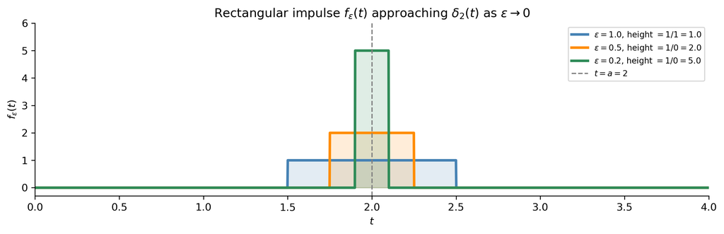

Figure 1

**Tip**

Each rectangle has **area exactly 1**, regardless of $\varepsilon$. As $\varepsilon\to 0$ the rectangle becomes the idealized delta function $\delta_a(t)$.

## The Delta Function — Sifting Property

The unit impulse $\delta_a(t)$ is a **generalized function** — it cannot be defined pointwise, only through how it acts under integration:

**Definition: Sifting Property**

$$\int_0^\infty \delta_a(t)\,\phi(t)\,dt = \phi(a)$$
for any continuous function $\phi(t)$.

Integrating $\delta_a$ against $\phi$ **picks out the value of $\phi$ at $t=a$**.

**Tip**

This is the *definition* of the delta function — not a derived property. It replaces the failed pointwise definition by specifying how $\delta_a$ *acts*, not what it *equals*.

## Sifting Property — Variable Limit and Verification

**Over a variable upper limit:**
$$\int_0^t \delta_a(\tau)\,\phi(t-\tau)\,d\tau = H(t-a)\,\phi(a).$$

The integral is zero for $t < a$ (the impulse hasn’t fired yet) and equals $\phi(a)$ for $t \geq a$.

**Returning to the velocity problem:** for the damped mass $mv'+v = \delta_a(t)$, $v(0)=0$, we had:
$$v(t) = \frac{1}{m}\int_0^t e^{-(t-\tau)/m}\,\delta_a(\tau)\,d\tau = \frac{H(t-a)}{m}\,e^{-(t-a)/m}. \checkmark$$

**Note**

Zero before the impulse, jumps to $1/m$ at $t=a$, then decays — exactly what a sharp blow should produce. The naive pointwise definition gave zero; the sifting property gives the correct physics.

## Laplace Transform of $\delta_a(t)$

Apply the sifting property with $\phi(t) = e^{-st}$:

$$\mathscr{L}[\delta_a(t)] = \int_0^\infty \delta_a(t)\,e^{-st}\,dt = e^{-as}.$$

**Key Formulas**

$$\mathscr{L}[\delta_a(t)] = e^{-as}, \quad a\ge 0.$$
$$\mathscr{L}[\delta_0(t)] = 1. \qquad \mathscr{L}^{-1}[1] = \delta_0(t).$$

**Tip**

Notice: $\mathscr{L}[\delta_a(t)] = e^{-as}$ is exactly the same factor that the **switching property** produces for time-delayed Heaviside terms. The inversion procedure is identical — a factor $e^{-as}$ always signals a delay of $a$, whether it came from a Heaviside function or a delta function.

## Alternate Derivation — Limiting Argument

We can also compute $\mathscr{L}[\delta_a(t)]$ by transforming the rectangular approximation $f_\varepsilon$ and taking $\varepsilon\to 0$:

$$\mathscr{L}[f_\varepsilon(t)] = e^{-as}\,\frac{\sinh(\varepsilon s/2)}{\varepsilon s/2}
\xrightarrow[\varepsilon\to 0]{\text{l'Hôpital}} e^{-as}\cdot 1 = e^{-as}. \checkmark$$

This confirms that the distributional definition (sifting property) and the limiting definition (rectangles shrinking to a spike) give the same Laplace transform.

**Note**

The limiting argument is the most physically transparent justification: as the impulse gets sharper and shorter while keeping unit area, its transform converges to $e^{-as}$. The sifting property then provides the rigorous mathematical foundation.

## Solving IVPs with Delta Forcing — The Method

**Procedure:** identical to previous Laplace methods.

1. **Transform** both sides. Replace $\delta_a(t)$ with $e^{-as}$ directly.
2. **Solve** for $X(s)$ algebraically.
3. **Invert** — the $e^{-as}$ factor is handled by the switching property, exactly as with $\mathscr{L}[H(t-a)f(t-a)] = e^{-as}F(s)$.

**Tip**

The only new ingredient is the formula $\mathscr{L}[\delta_a(t)] = e^{-as}$. Everything else — partial fractions, the switching property, the table — works exactly as before.

## Example 3.26 — IVP with a Unit Impulse

Solve $x''+x' = \delta_2(t)$, $x(0)=x'(0)=0$.

**Step 1 — Transform** ($\mathscr{L}[\delta_2(t)] = e^{-2s}$):
$$s^2X + sX = e^{-2s} \implies X(s) = \frac{e^{-2s}}{s(s+1)}.$$

**Step 2 — Base inverse transform** (partial fractions or table):
$$\mathscr{L}^{-1}\!\left[\frac{1}{s(s+1)}\right] = 1 - e^{-t}.$$

**Step 3 — Switching property** ($e^{-2s}$ signals a delay of 2):
$$x(t) = \bigl(1-e^{-(t-2)}\bigr)\,H(t-2).$$

| Region | $x(t)$ | Meaning |
| --- | --- | --- |
| $0\le t < 2$ | $0$ | System at rest |
| $t=2$ | impulse fires | Activated |
| $t\to\infty$ | $\to 1$ | Approaches steady state |

## Example 3.26 — Solution Plot

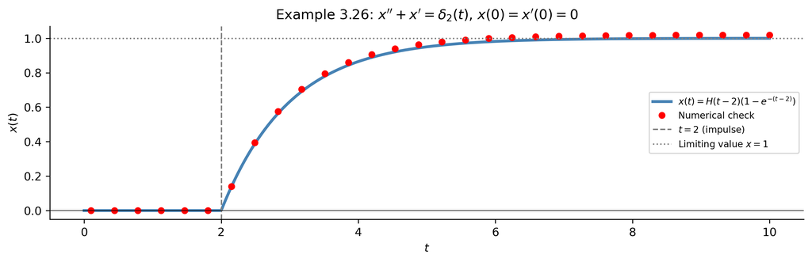

Figure 2

# Input–Output Systems

## Transfer Functions

Many engineering problems fit the **input–output** framework:

$$\underbrace{f(t)}_{\text{input}}\;\longrightarrow\;\underbrace{ax''+bx'+cx=f(t),\;x(0)=x'(0)=0}_{\text{system}}\;\longrightarrow\;\underbrace{x(t)}_{\text{output (forced response)}}$$

In the $s$-domain: $X(s) = K(s)\,F(s)$, where

**Transfer Function**

$$K(s) = \frac{1}{as^2+bs+c}.$$
Knowing $K(s)$ gives **complete knowledge** of the system’s response to any input.

By the convolution property, the time-domain forced response is:
$$x(t) = k(t)*f(t) = \int_0^t k(t-\tau)\,f(\tau)\,d\tau, \qquad k(t)=\mathscr{L}^{-1}[K(s)].$$

## Time Domain vs. Transform Domain

**Time domain**

$$x(t) = k(t) * f(t)$$

**Convolution** — weighted accumulation of past inputs against the system kernel $k$

**Transform domain**

$$X(s) = K(s)\,F(s)$$

**Multiplication** — simple algebra

$$\text{Convolution in time} \;\longleftrightarrow\; \text{Multiplication in } s.$$

This is one of the deepest reasons Laplace transforms are so powerful for engineering: a complicated time-domain operation becomes trivial algebra in the $s$-domain.

## Example 3.27 — General Impulse Response

If $f(t) = \delta_{t_0}(t)$, then $F(s) = e^{-t_0 s}$ and:

**Transform domain:** $X(s) = K(s)\,e^{-t_0 s}$.

**Time domain** (sifting property applied to the convolution):
$$x(t) = k(t)*\delta_{t_0}(t) = \int_0^t k(t-\tau)\,\delta_{t_0}(\tau)\,d\tau = H(t-t_0)\,k(t-t_0). \;\square$$

**Note**

The impulse response is a **time-shifted copy of $k(t)$**, switched on at $t=t_0$. This is why $k(t)$ is called the *impulse response function* of the system.

## Example 3.28 — Damped Oscillator Impulse Response

Solve $x''+2x'+5x = \delta_{t_0}(t)$, $x(0)=x'(0)=0$.

**Transfer function:**
$$K(s) = \frac{1}{s^2+2s+5} = \frac{1}{2}\cdot\frac{2}{(s+1)^2+4}$$

so $k(t) = \mathscr{L}^{-1}[K(s)] = \tfrac{1}{2}\,e^{-t}\sin 2t$.

**Impulse response** (by Example 3.27):
$$x(t) = H(t-t_0)\,\frac{1}{2}\,e^{-(t-t_0)}\sin 2(t-t_0). \;\square$$

Zero until $t=t_0$; then **damped oscillation** for $t>t_0$. See Figure 3.10 in the text for $t_0=2$.

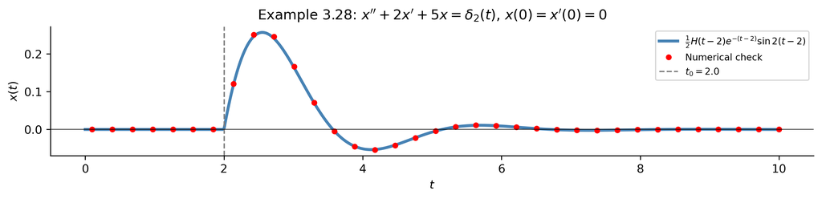

Figure 3

# Summary

## Key Formulas — Convolution

| Concept | Formula |
| --- | --- |
| Definition | $(x*y)(t) = \displaystyle\int_0^t x(\tau)\,y(t-\tau)\,d\tau$ |
| Convolution property | $\mathscr{L}[x*y] = X(s)\,Y(s)$ |
| Inverse form | $\mathscr{L}^{-1}[X(s)\,Y(s)] = (x*y)(t)$ |
| Commutativity | $(x*y)(t) = (y*x)(t)$ |
| Arbitrary forcing | $x(t) = \frac{1}{k}\int_0^t f(\tau)\sin k(t-\tau)\,d\tau + \cdots$ |

## Key Formulas — Delta Function and Transfer Function

| Concept | Formula |
| --- | --- |
| Sifting property | $\displaystyle\int_0^\infty \delta_a(t)\,\phi(t)\,dt = \phi(a)$ |
| $\mathscr{L}$ of delta | $\mathscr{L}[\delta_a(t)] = e^{-as}$ |
| Inverse | $\mathscr{L}^{-1}[e^{-as}] = \delta_a(t)$ |
| Transfer function | $K(s) = 1/(as^2+bs+c)$ |
| Forced response (s-domain) | $X(s) = K(s)\,F(s)$ |
| Forced response (time) | $x(t) = k(t)*f(t)$ |

## Common Pitfalls

- $\mathscr{L}[x(t)y(t)] \neq X(s)Y(s)$ — the transform of a *product* is **not** the product of the transforms. The convolution $\mathscr{L}^{-1}[X(s)Y(s)] = (x*y)(t)$ is something entirely different.
- $\delta_a(t)$ is **not an ordinary function**. Never try to evaluate it pointwise. It is defined only through the sifting property.
- When using commutativity, **check both arrangements** of the convolution integrand and pick the one that is easier to integrate.
- A factor $e^{-as}$ in $X(s)$ always signals a **time delay of $a$** — handle it with the switching property, whether it came from a Heaviside function or a delta function.

## References

Logan, J David. 2015. *A First Course in Differential Equations, Third Edition*.